# Basic Skills in Visualing Data and Exporatory Data Analysis Using R

## Kobe Bryant’s performance indicators over the championship years

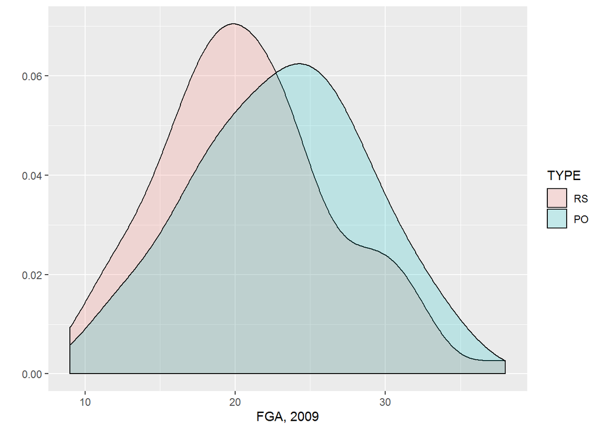

Density plot for FGA for regular season and playoff in 2000 and 2009.

```r
qplot(VAR, data=xxx1, geom="density",
fill = TYPE, alpha = I(0.2))+
xlab("FGA, 2009")
```

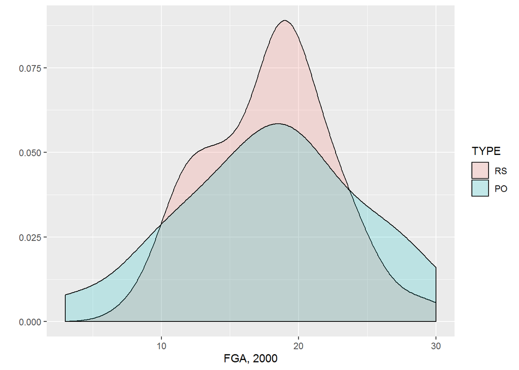

Density plot for FGA for regular season and playoff in 2000 and 2009.

```r
qplot(VAR, data=xxx2, geom="density",
fill = TYPE, alpha = I(0.2))+
xlab("FGA, 2000")
```

This pattern is more clear when ridgeline charts are used to visualize the distributions in the seasons of 2009 and 2000

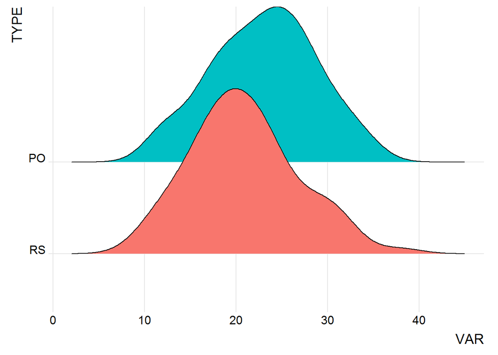

FGA: 2009

```r
library(ggridges)
ggplot(xxx1, aes(x=VAR,y=TYPE,fill = TYPE)) +
  geom_density_ridges() +
  theme_ridges() +
  theme(legend.position = "none")
```

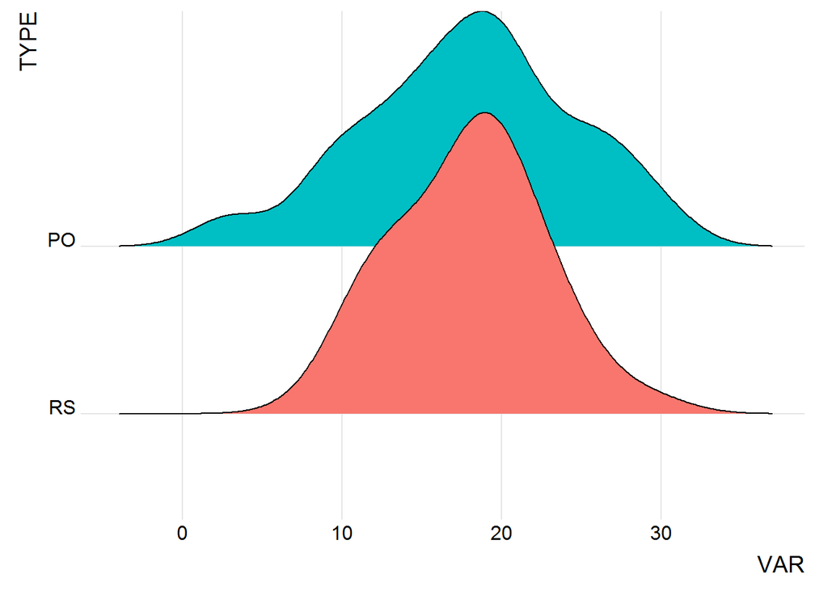

FGA: 2000

```r
ggplot(xxx2, aes(x=VAR,y=TYPE,fill = TYPE)) +
  geom_density_ridges() +
  theme_ridges() +
  theme(legend.position = "none")
```

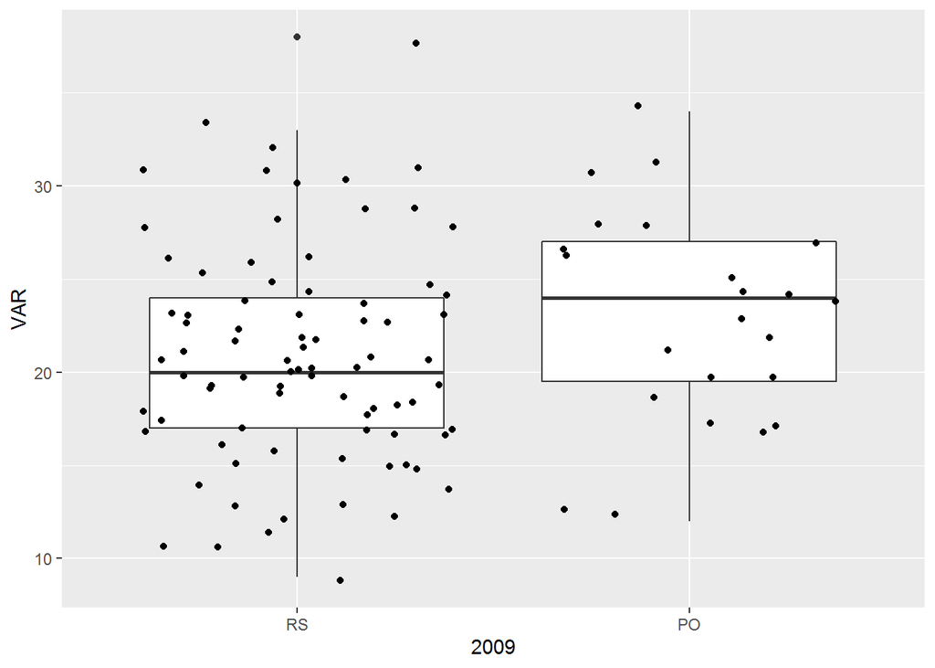

Boxplot for FGA for regular season and playoff in 2000 and 2009.

```r
qplot(TYPE, VAR, data = xxx1, geom = c("boxplot", "jitter"))+
xlab("2009")
```

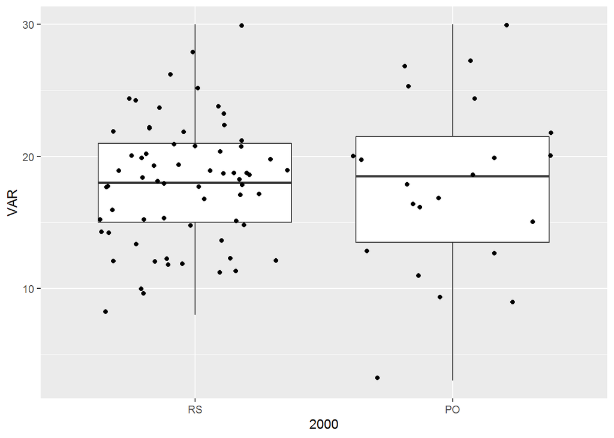

Boxplot for FGA for regular season and playoff in 2000 and 2009.

```r
qplot(TYPE, VAR, data = xxx2, geom = c("boxplot", "jitter"))+
xlab("2000")
```

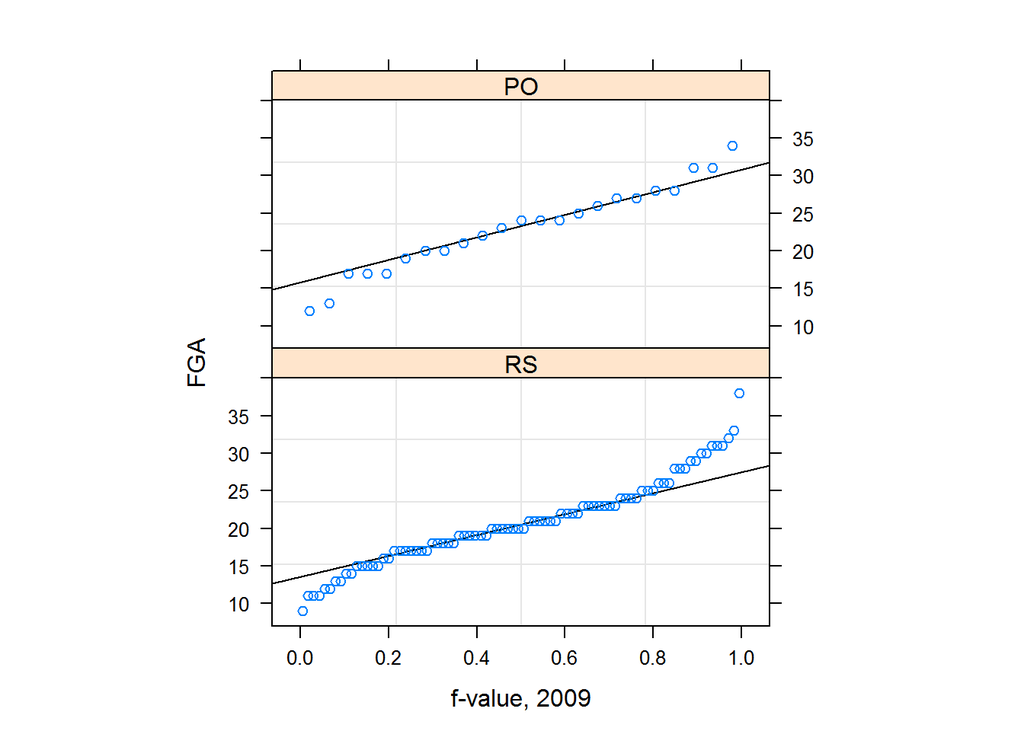

quentile plot for FGA for regular season and playoff in 2000 and 2009.

```r
qqmath(~ VAR | TYPE,
        distribution=qunif,
        data=xxx1,
           layout=c(1,2),
             prepanel = prepanel.qqmathline,
            panel = function(x, ...) {
            panel.grid()
            panel.qqmathline(x, ...)
            panel.qqmath(x, ...)
            },
        aspect=0.5,
        xlab = "f-value, 2009",
        ylab="FGA")
```

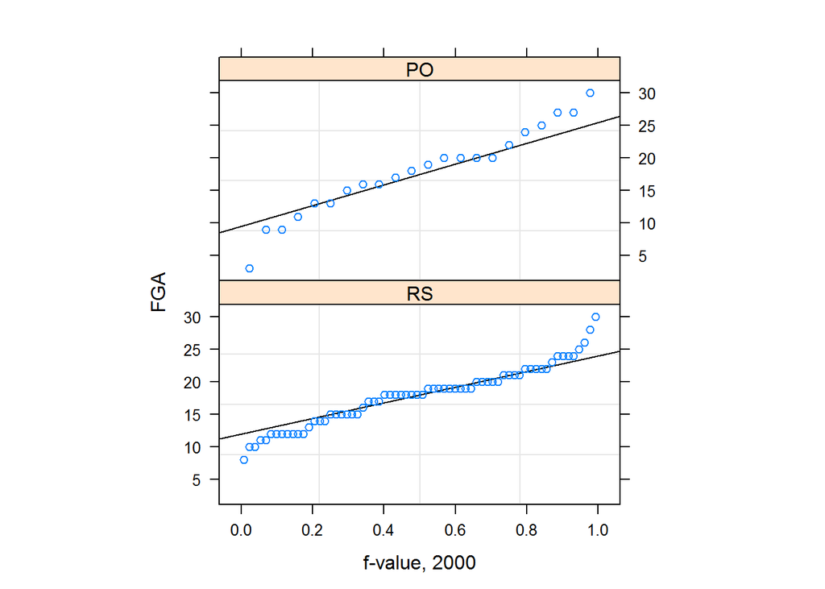

quentile plot for FGA for regular season and playoff in 2000 and 2009.

```r
qqmath(~ VAR | TYPE,
        distribution=qunif,
        data=xxx2,
           layout=c(1,2),
             prepanel = prepanel.qqmathline,
            panel = function(x, ...) {
            panel.grid()
            panel.qqmathline(x, ...)
            panel.qqmath(x, ...)
            },
        aspect=0.5,
        xlab = "f-value, 2000",
        ylab="FGA")
```

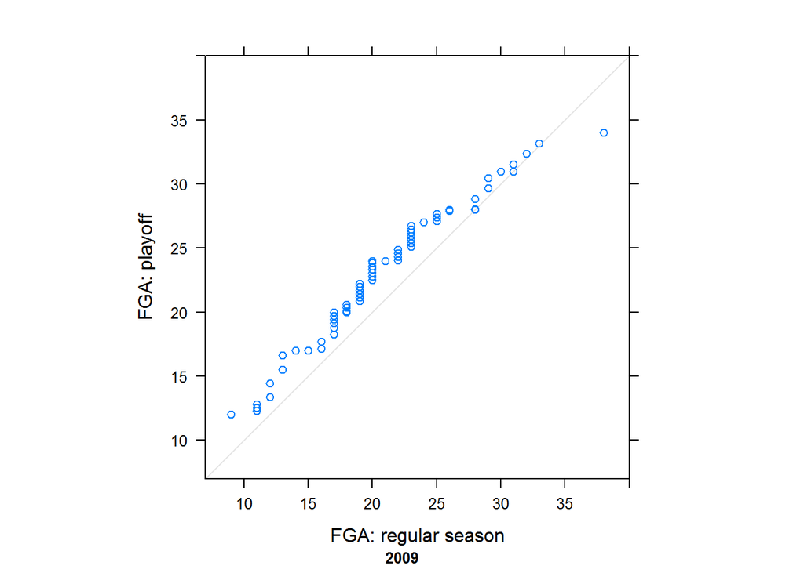

qqplot for FGA for regular season and playoff in 2000 and 2009.

```r
qq(xxx1$TYPE ~ xxx1$VAR,data=xxx1,
        aspect=1,
        sub = list("2009",cex=.8),
        xlab = "FGA: regular season",
        ylab = "FGA: playoff")
```

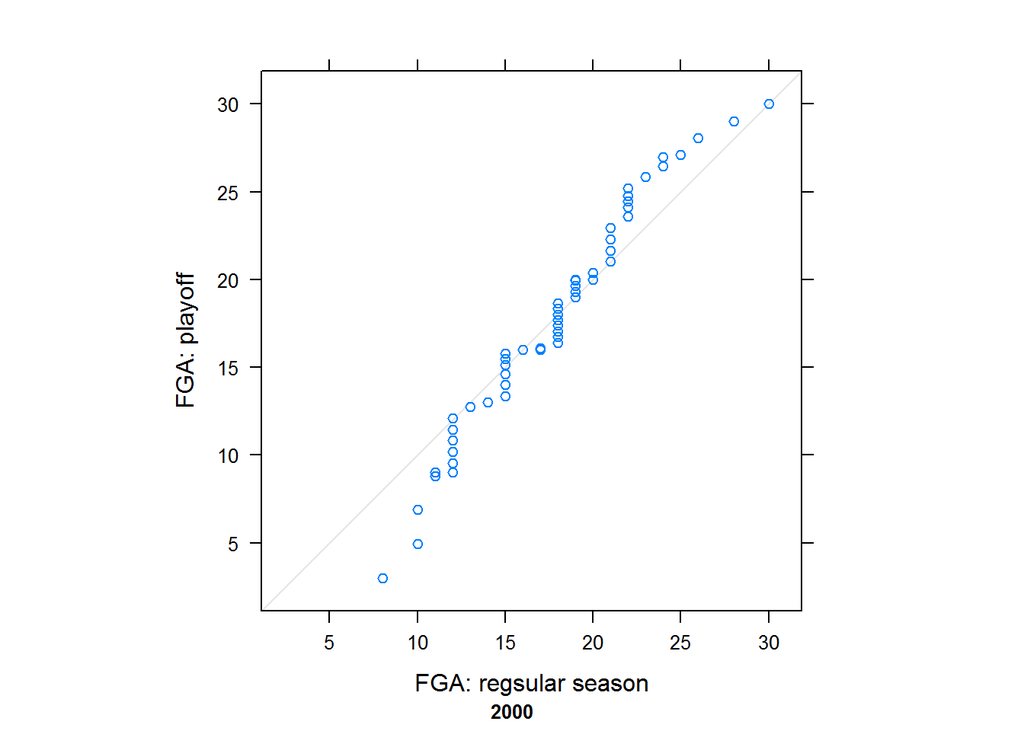

qqplot for FGA for regular season and playoff in 2000 and 2009.

```r
qq(xxx2$TYPE ~ xxx2$VAR,data=xxx2,
        aspect=1,
        sub = list("2000",cex=.8),
        xlab = "FGA: regsular season",
        ylab = "FGA: playoff")
```

# Normal probability plot

## Introduction

In this chapter we discuss graphical tools to vizualise the shape of a distribution. Some of the tools, histograms and boxplots were discuused in the privious chapters. Using histograms and boxplots we were able to investigate the shape of teh distribution focusing on the follwing issues:

- How nearly symmetric the distribution of the data is.
- Whether the distribution of the data is single-peaked, or whether it is multi-peaked.
- Whether it is skewed.
- Whether a few values are far away from the rest.
- Whether there are concentrations of data.
- Whether there are gaps in the data.

## Normal probability plot

A qq normal plot is a graphical disply to investigate how now nearly is the sample to a normal distribution.
$$q_{\mu,\sigma}(f)=\mu+\sigma q_{0,1}(f)$$
For example, the $2.5 % $ quantile of the standard normal distribution is -1.96. For $N(2,5^{2})$ we have
$$q_{2,5}(2.5 \% )=2+ 5 \times - 1.96=-7.8$$

```r
qnorm(0.025,0,1)
```

```
## [1] -1.959964
```

```r
qnorm(0.025,2,5)
```

```
## [1] -7.79982
```

```r
-1.96*5+2
```

```
## [1] -7.8
```

## YouTube tutorial: QQ-Plots in RStudio

For a short online YouTube tutorials by UTSSC, about normal probability plot using R studio see [YTVD12](https://www.youtube.com/watch?v=louihSVsMC0).

## Examples

In this section we focus on few examples and use normal probability plots to access the shape of the distributions.

### Sample fron N(0,1)

We use the function qqnorm() to produce the normal probabilty plot. For this example, since data were sampled from $N(0,1)$, we expect that all points in the normal probability plot will lay on the on the $45^o$ line.

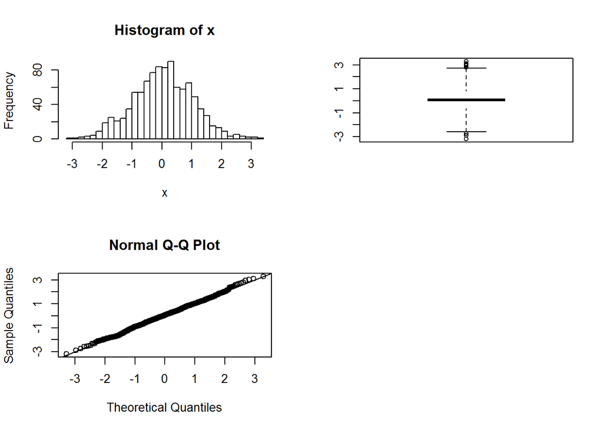

Random sample from N(0,1).

```r
x <- rnorm(1000, 0, 1)
par(mfrow = c(2, 2))
hist(x, nclass = 25, col = 0)
boxplot(x, boxcol = 0, medcol = 1)
qqnorm(x)
abline(0, 1)
```

### Sample fron N(2,1)

The sample was drawn from $N(2,1)$, i.e., it represents a shift model with the same variabiliy comapre to $N(0,1)$. In this case we expect that all points i the normal probability plot will lay above and parallel to the $45^{o}$ lines.

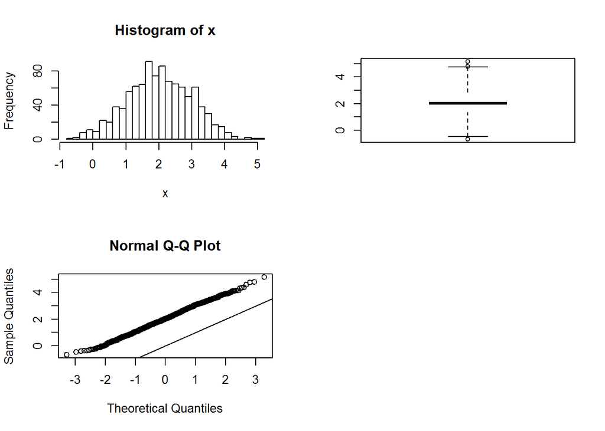

Random sample from N(2,1).

```r
x <- rnorm(1000, 2, 1)
par(mfrow = c(2, 2))
hist(x, nclass = 25, col = 0)
boxplot(x, boxcol = 0, medcol = 1)
qqnorm(x)
abline(0, 1)
```

### Sample fron N(0,2)

In this example, the same was drawn from $N(0,2^2)$ which means that the mean is the same as $N(0,1)$ but the variability is higher. We expect the points in the normal probability plot to form a straight line with higher slope than 1.

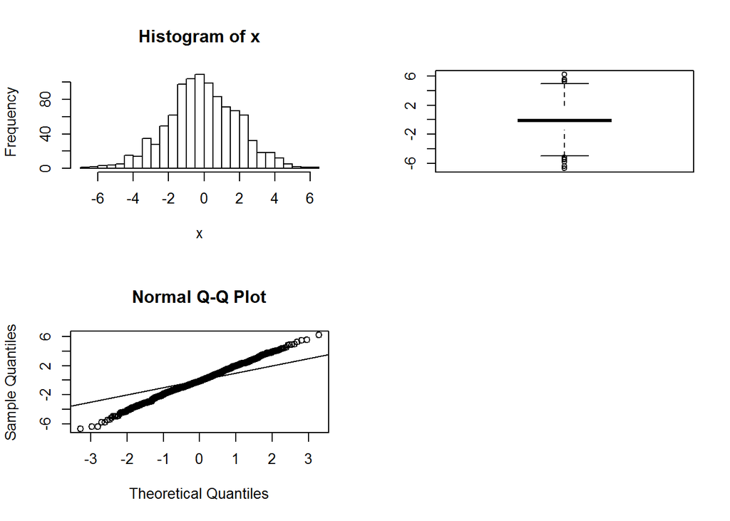

Random sample from N(0,2).

```r
x <- rnorm(1000, 0, 2)
par(mfrow = c(2, 2))
hist(x, nclass = 25, col = 0)
boxplot(x, boxcol = 0, medcol = 1)
qqnorm(x)
abline(0, 1)
```

### Sample fron $t_{(3)}$

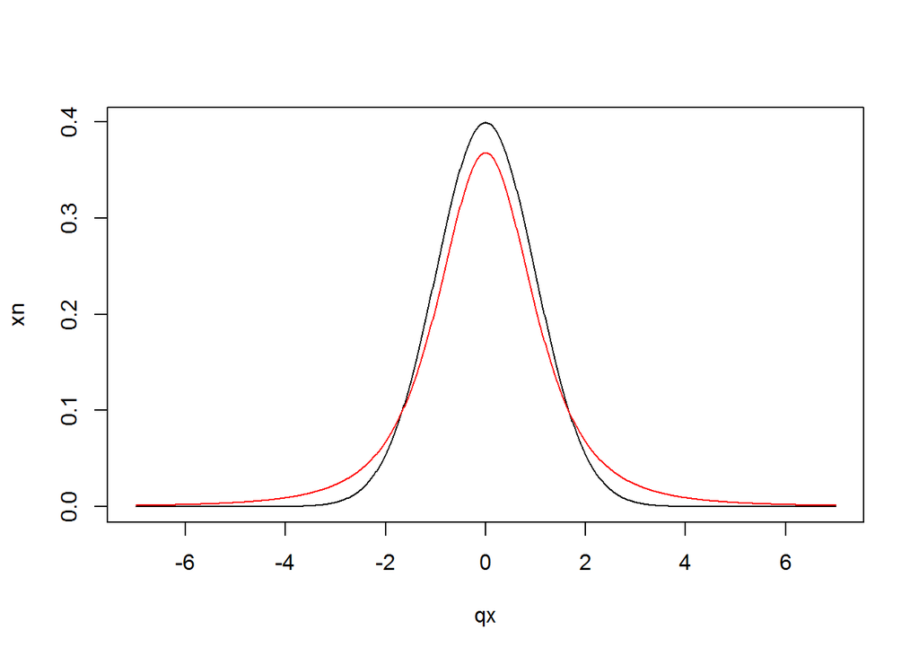

Density plot for N(0,1) and t(3).

```r
par(mfrow = c(1, 1))
qx <- seq(from = -7, to = 7, length = 1000)
xn <- dnorm(qx, mean = 0, sd = 1)
xt <- dt(qx, 3)
plot(qx, xn, xlim = c(-7, 7), type = "l")
lines(qx, xt, col=2)
```

This implies that in the normal probability plot we expect that the pots will lay on the $45^o$ line in the center but with more extreme values.

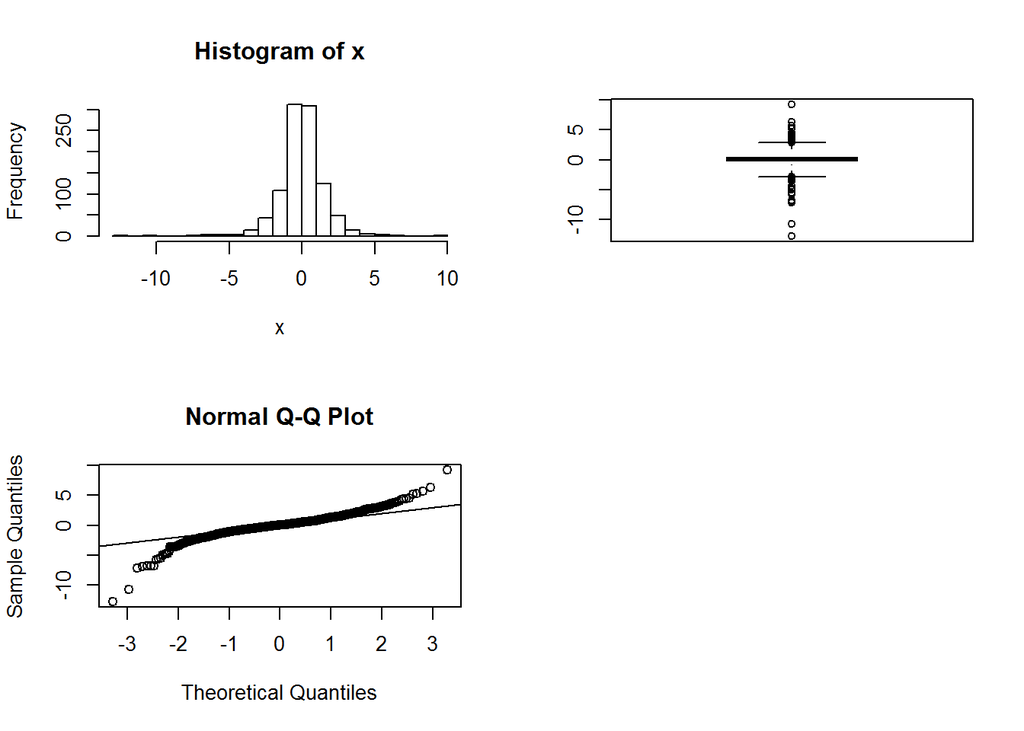

Random sample from t(3).

```r
x <- rt(1000, 3)
par(mfrow = c(2, 2))
hist(x, nclass = 25, col = 0)
boxplot(x, boxcol = 0, medcol = 1)
qqnorm(x)
abline(0, 1)
```

### Sample fron $U(-3,3)$

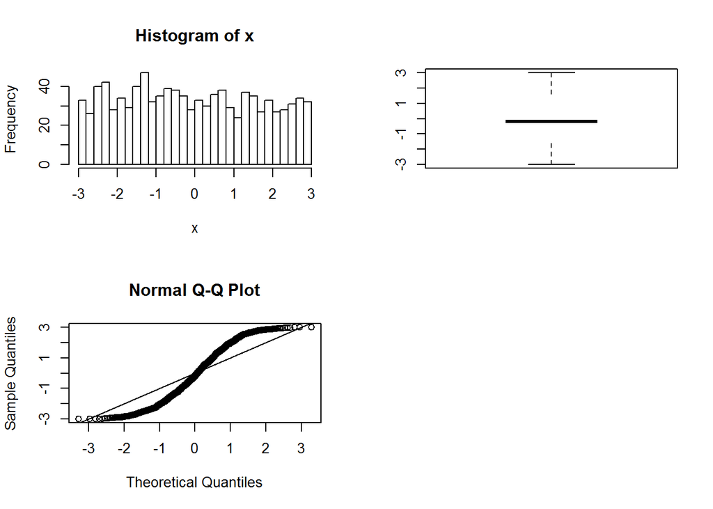

Random sample from U(-3,3).

```r
x <- runif(1000, -3, 3)
par(mfrow = c(2, 2))
hist(x, nclass = 25, col = 0)
boxplot(x, boxcol = 0, medcol = 1)
qqnorm(x)
abline(0, 1)
```

## Kobe Bryant’s performance indicators over the championship years

In this section we focus on the distribution of the average field goal success ( FG$\%$) and game score (GmSc) in Bryant’s five championship years and in particular we investigate if the distribution f these variables can be approximated by a normal distribution.

### FG$\%$

The multi-way qqnormal plot for the FG$\%$ reveals that the distribution of the variable exhibit a exhibit a departure from a normal distribution approximation.

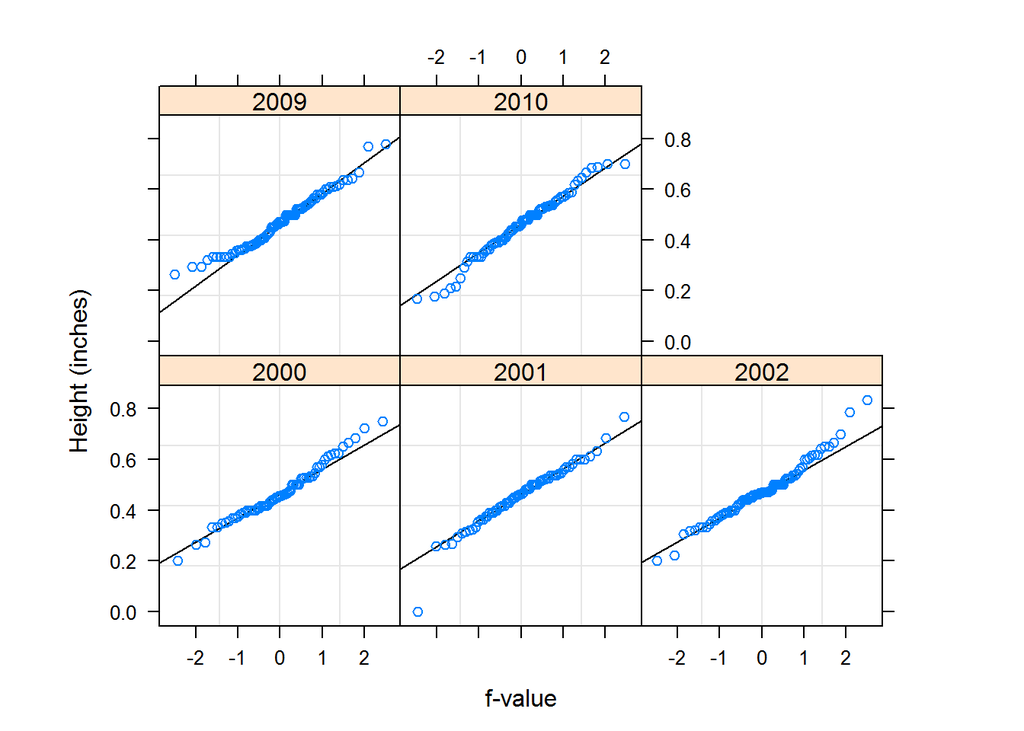

normal probability plot for the distribution of FG%.

```r
qqmath(~ FG. | year.i,
        distribution = qnorm,
        data=xx21.b,
           layout=c(3,2),
             prepanel = prepanel.qqmathline,
            panel = function(x, ...) {
            panel.grid()
            panel.qqmathline(x, ...)
            panel.qqmath(x, ...)
            },
        aspect=1,
        xlab = "f-value",
        ylab="Height (inches)")
```

For example the bi-model distribution in 2009 or the heavy tailed distribution in 2010.

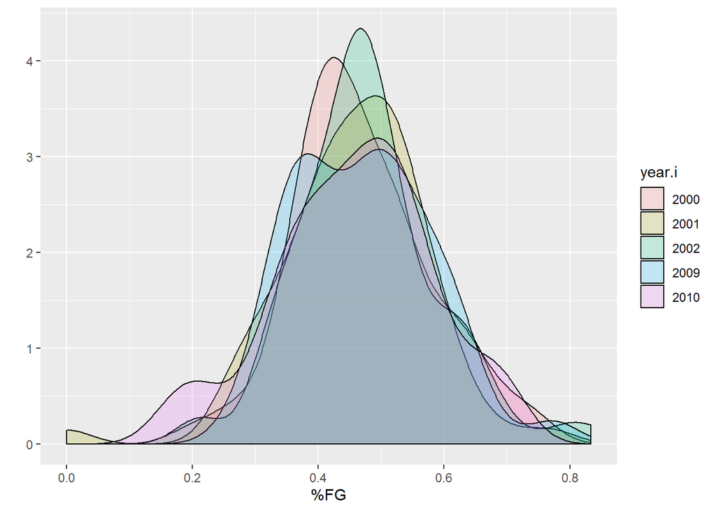

Density plot for the distribution of FG%.

```r
qplot(FG., data=xx21.b, geom="density",
fill = year.i, alpha = I(0.2))+
xlab("%FG")
```

These patterns can be seen more clearly when a ridge plot is used to visualize the data.

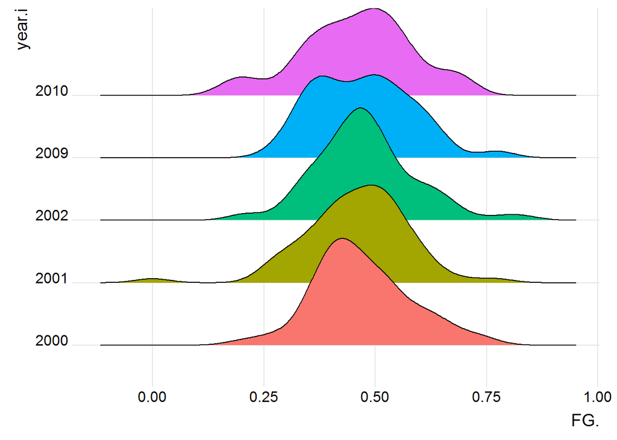

```r
library(ggridges)
ggplot(xx21.b, aes(x=FG.,y=year.i,fill = year.i)) +
  geom_density_ridges() +
  theme_ridges() +
  theme(legend.position = "none")
```

### Game score (GmSc)

The multi-way qqnormal plot for game score reveals that the distributions are close to normal distributions.

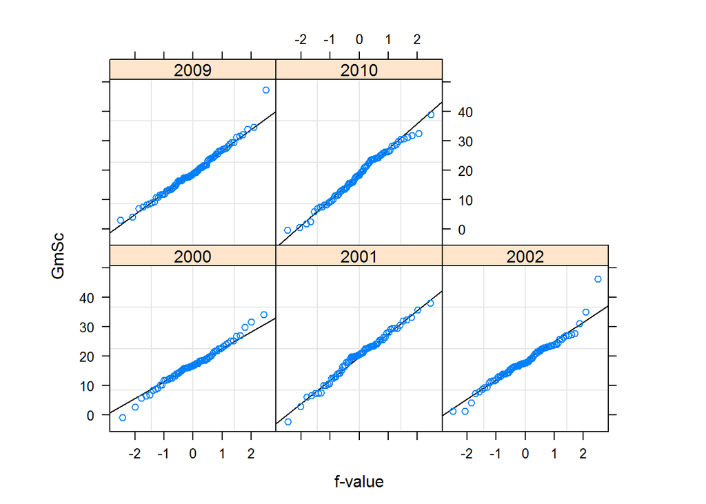

normal probability plot for the distribution of GmSc

```r
qqmath(~ GmSc | year.i,
        distribution = qnorm,
        data=xx21.b,
           layout=c(3,2),
             prepanel = prepanel.qqmathline,
            panel = function(x, ...) {
            panel.grid()
            panel.qqmathline(x, ...)
            panel.qqmath(x, ...)
            },
        aspect=1,
        xlab = "f-value",
        ylab="GmSc")
```

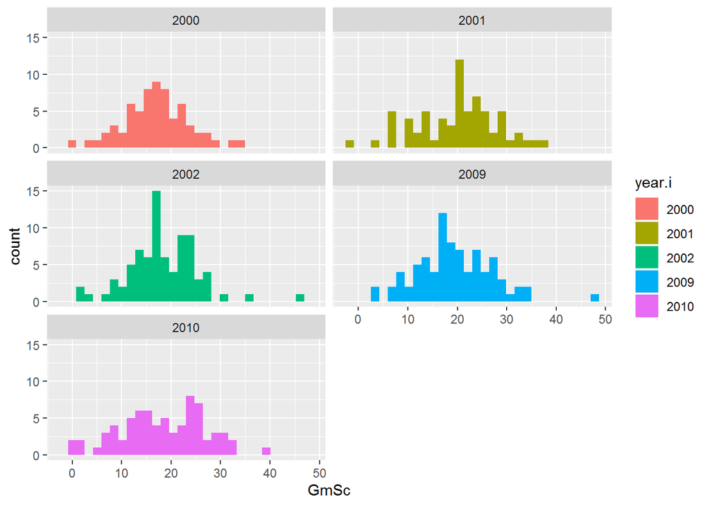

Histogram for the distribution of GmSc

```r
ggplot(xx21.b, aes(GmSc,fill = year.i)) +
geom_histogram() +
facet_wrap(~year.i,ncol = 2)
```